# Multivariate analysis

# Introduction

In this tutorial, we will perform multivariate analysis on NMR data using the `metabom8` package. We will cover Principal Component Analysis (PCA) and Orthogonal Partial Least Squares Discriminant Analysis (OPLS-DA). This analysis helps in understanding the underlying structure of the data and identifying differences between groups.

## Prerequisites

Make sure you have the following libraries installed:

```r
install.packages("metabom8")
install.packages("readr")
install.packages("ggplot2")
```

## Setting Up the Environment

Let’s set our working directory and load the necessary libraries.

```r
setwd('/Volumes/AEIWZ A/Project/AG-Bio')
library(metabom8)
library(readr)
```

```r
library(ggplot2)
```

## Loading the Data

We will load the NMR data, chemical shift values (ppm), and metadata from URLs:

```r
# Load data
X = read.csv('https://raw.githubusercontent.com/KKUPhenomeCentre/ag-bio/main/src/data/leaf_norm.csv')
ppm = read.csv('https://raw.githubusercontent.com/KKUPhenomeCentre/ag-bio/main/src/data/leaf_ppm.csv')
meta = read.csv('https://raw.githubusercontent.com/KKUPhenomeCentre/ag-bio/main/src/data/Metadata.csv')

#Data cleaning
X = as.matrix(X)
colnames(X) = as.numeric(ppm)
# Convert ppm to numeric
ppm = as.numeric(ppm)
```

## Visualizing Spectra

We can visualize the spectra to get an overview of the data:

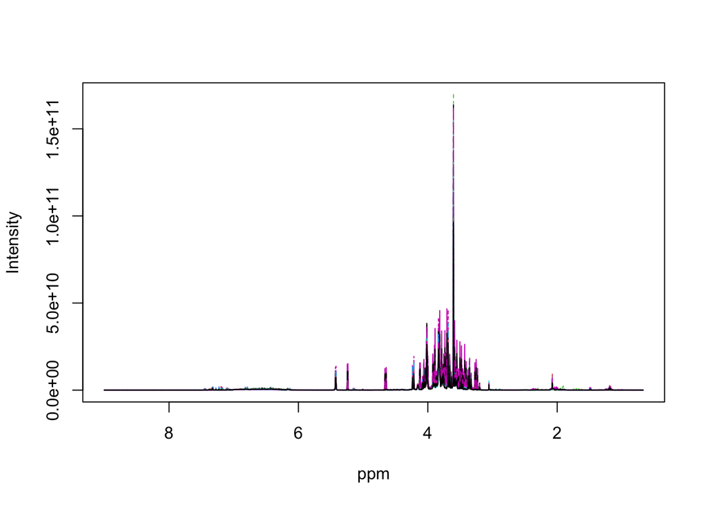

```r
matspec(X, ppm, shift = range(ppm), interactive = FALSE)
```

## Setting Up for Analysis

For reproducibility, we will set a seed and prepare our data:

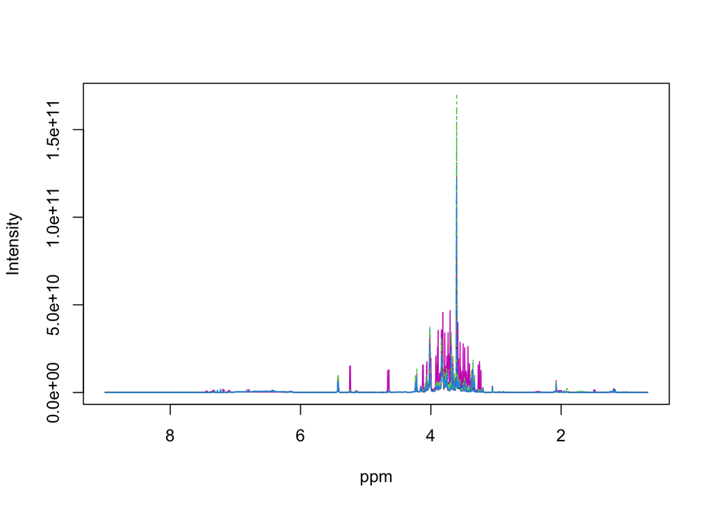

```r
set.seed(180)

# Declare variables
Xn <- X  # PQN-normalised NMR data matrix
ppm <- ppm  # chemical shift vector in ppm
meta <- meta  # spectrometer metadata
an <- meta  # sample annotation

# Visualize first ten spectra
matspec(Xn[1:10,], ppm, shift = c(0, 10), interactive = FALSE)
```

## Performing PCA

Now, we will perform PCA to reduce dimensionality and visualize the data:

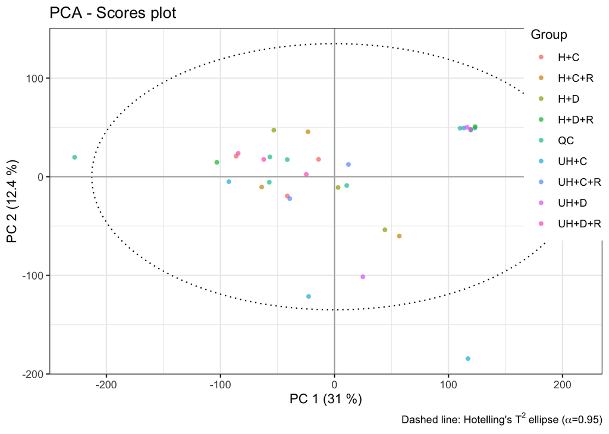

```r
# Perform PCA
pca_model = pca(X = Xn, pc = 2, scale = 'UV', center = TRUE)

# Plot PCA results: scores of the first two components
plotscores(obj = pca_model, pc = c(1, 2), an = list(Group = an$Class), title = 'PCA - Scores plot')
```

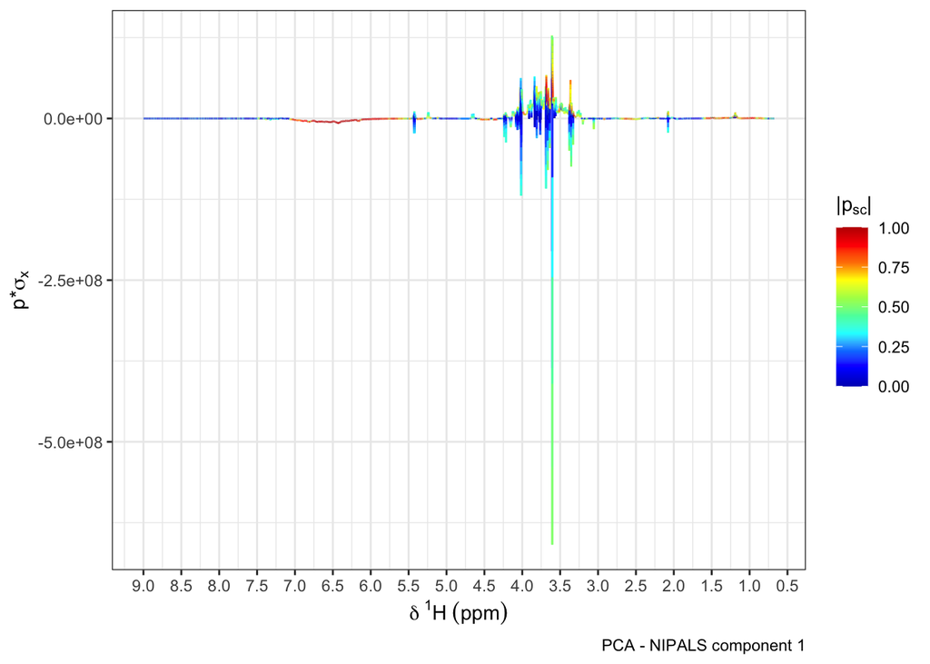

```r
# Plot PCA loadings
plotload(mod = pca_model, pc = 1)  # 1st principal component
```

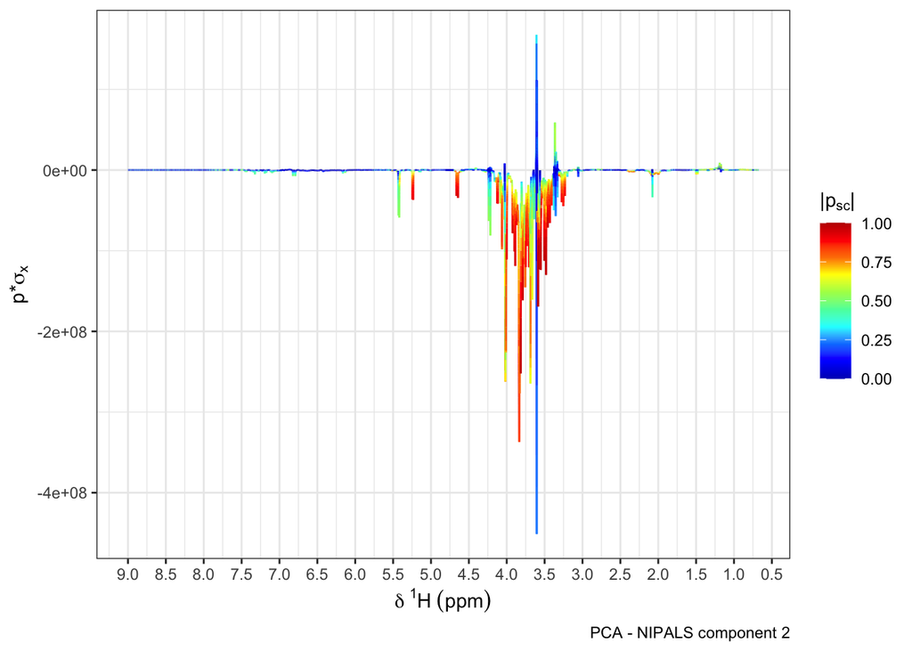

```r
plotload(mod = pca_model, pc = 2)  # 2nd principal component
```

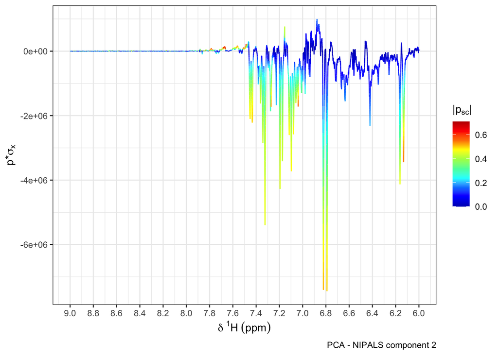

```r
plotload(mod = pca_model, pc = 2, shift = c(6, 9))  # 2nd principal component in region 6-9 ppm
```

## OPLS-DA Analysis

Next, we will perform OPLS-DA to classify the samples based on their classes:

```r
# Get index of two classes
idx = an$Class %in% c('H+C', 'UH+D')

X = Xn[idx,]
Y = an$Class[idx]

# Filter NaN
X = na.omit(X)

# Train O-PLS model
opls.model = opls(X, Y)
```

```
## Performing discriminant analysis.
```

```
## Setting CV k-fold parameter to 3. Number of observations in group 1 is too low (n=3) for k=7.
```

```
## An O-PLS-DA model with 1 predictive and 1 orthogonal components was fitted.
```

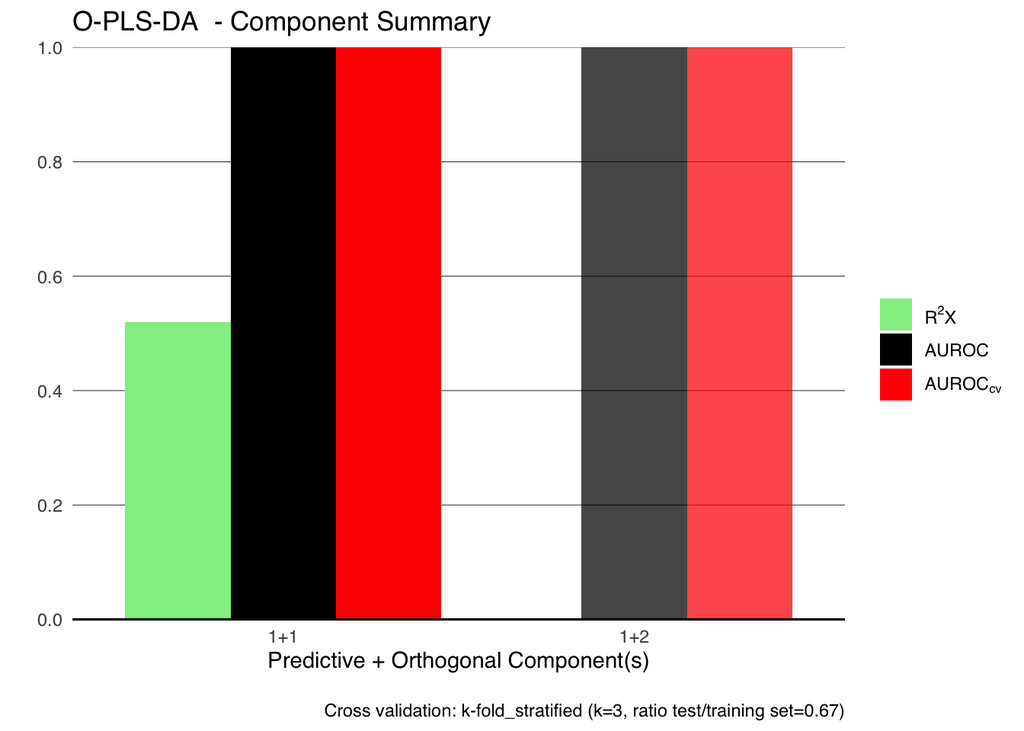

```r
# View model summary
opls.model@summary
```

```
##   PC_pred PC_orth  R2X AUROC AUROC_CV
## 1       1       1 0.52     1        1
## 2       1       2   NA     1        1
```

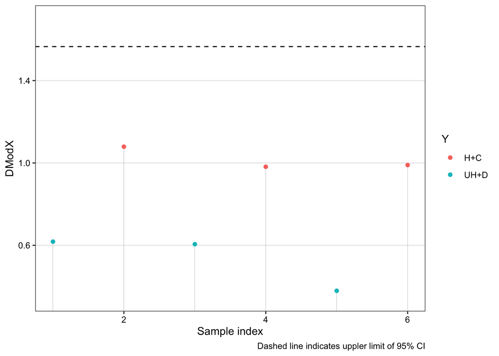

```r
# Calculate model distances
distX = dmodx(mod = opls.model, plot = TRUE)
```

### Plotting OPLS Scores

Now, we will visualize the OPLS scores:

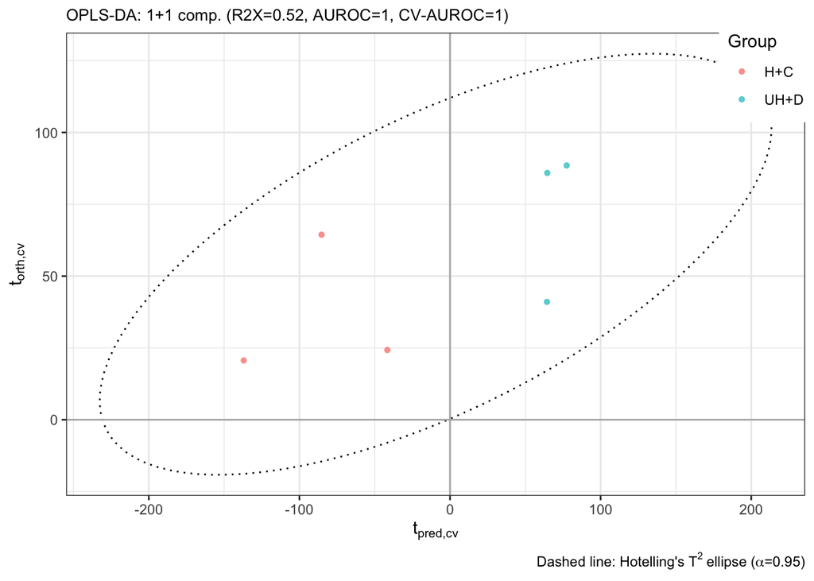

```r
plotscores(obj = opls.model, an = list(
  Group = an$Class[idx],          # Colour according to class
  Timepoint = an$Timepoint[idx]), # Timepoint can be ignored for this analysis
  title = 'OPLS - Scores plot',    # Plot title
  cv.scores = TRUE)                 # Visualize cross-validated scores
```

### Plotting OPLS Loadings

We will also plot the loadings from the OPLS model:

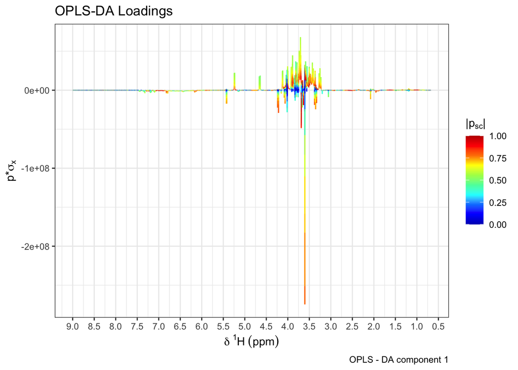

```r
plotload(opls.model, title = 'OPLS-DA Loadings', shift = c(0.5, 9.5))
```

### Overlayed Spectra with Backscaled Loadings

Finally, we can visualize the overlayed spectra with backscaled loadings:

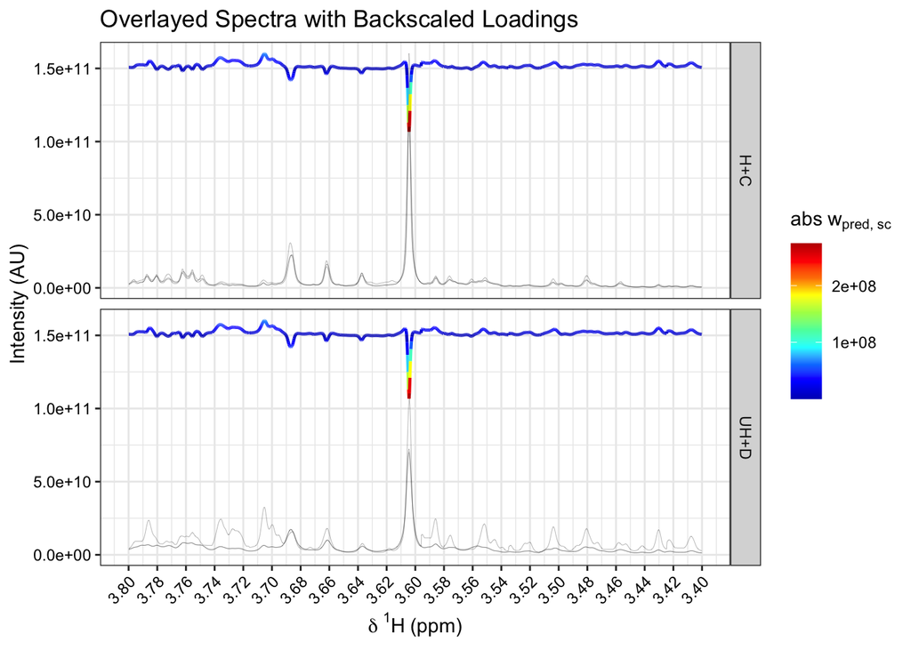

```r
specload(mod = opls.model, shift = c(3.4, 3.8), an = list(
  facet = an$Class[idx]),
  type = 'backscaled',
  alp = 0.5,
  title = 'Overlayed Spectra with Backscaled Loadings')
```